# Solution to Exam 2010 problem 5

### 02409 Multivariate Statistics

`Week K`

An experiment has been conducted to assess the effect of four nitrogen treatments in three blocks on several variables measured for Jonathan apples. Here we consider three of them: $y_1$: total nitrogen, $y_2$: potassium, $y_3$: calcium. We will consider the multivariate response: $(y_1,y_2,y_3)'$. The results are given in the table below.

```r
Nitrogen <- data.frame(Treatment = c(1,1,1,2,2,2,3,3,3,4,4,4),
                       Block = c(1,2,3,1,2,3,1,2,3,1,2,3),
                       y1 = c(3580,2870,3110,3040,5810,3010,4250,6950,4680,4700,7230,5760),
                       y2 = c(8220,7550,8180,10760,11340,9830,11830,12910,11010,8830,10840,9200),
                       y3 = c(244,272,297,138,165,159,169,148,224,148,120,147))
Nitrogen$Block <- as.factor(Nitrogen$Block)
Nitrogen$Treatment <- as.factor(Nitrogen$Treatment)
Nitrogen
```

```
##    Treatment Block   y1    y2  y3
## 1          1     1 3580  8220 244
## 2          1     2 2870  7550 272
## 3          1     3 3110  8180 297
## 4          2     1 3040 10760 138
## 5          2     2 5810 11340 165
## 6          2     3 3010  9830 159
## 7          3     1 4250 11830 169
## 8          3     2 6950 12910 148
## 9          3     3 4680 11010 224
## 10         4     1 4700  8830 148
## 11         4     2 7230 10840 120
## 12         4     3 5760  9200 147
```

We have three variables $y_1$, $y_2$, and $y_3$, and two effects ‘Treatment’ and ‘Block’.

As we are interested in the effects it is a *two-sided MANOVA*, which we will use for the analysis, see section 4.3.2 page 304.

We are further supplied with a R-script, that we run. I will show how to solve the exercise by hand and show the relevant parts in the R-output as well as general comments at the end of the document.

## Question 5.1.

The usual test statistic for treatment effect. We use theorem 4.26 page 306.

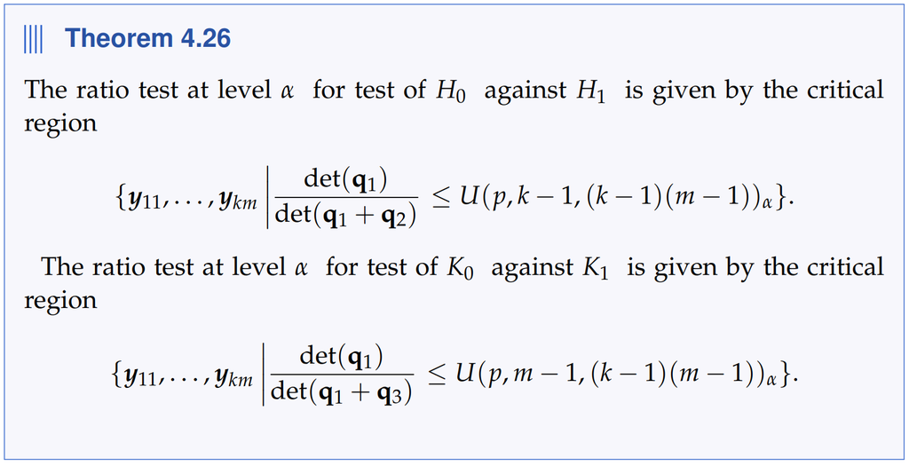

$p$ is the dimensionality of our observations, i.e. $p=3$. If we denote treatment by $k$, and blocks by $h$, we get $k=4$ and $h=3$:

The test for treatment is then:

$$U(p,k-1,(k-1)(m-1)) = U(3,4-1,(4-1)(3-1)) = U(3,3,6)$$

The answer is thus 3.

## Question 5.2.

The transformation of the test statistic for “no block effect” to the F-distribution?

We can write it up from the theorem above:

$$U(p,m-1,(k-1)(m-1)) = U(3,3-1,(4-1)(3-1)) = U(3,2,6)$$

For the transformation between the U- and F-distribution we use theorem 4.22 on page 296:

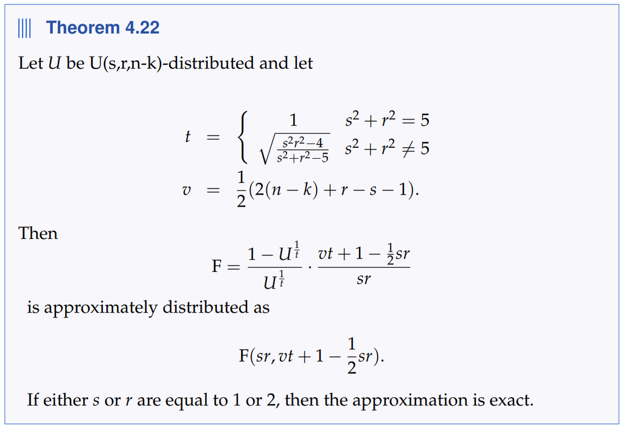

As we have $\nu_2 = 2$ the transformation is exact, and the answer is 5.

## Results in R:

```r
dep_vars <- cbind(Nitrogen$y1,Nitrogen$y2,Nitrogen$y3)

lmfit <- manova(dep_vars ~ Treatment + Block,data=Nitrogen)
Ano.fit <- Anova(lmfit,test = 'Wilks')
# other tests (Pillai, Hotelling-Lawley and Roy's Greatest Root) are also available.
Ano.fit
```

```
##
## Type II MANOVA Tests: Wilks test statistic
##           Df test stat approx F num Df den Df   Pr(>F)
## Treatment  3  0.002023  12.9511      9 9.8856 0.000222 ***
## Block      2  0.193450   1.6981      6 8.0000 0.238705
## ---
## Signif. codes:  0 '***' 0.001 '**' 0.01 '*' 0.05 '.' 0.1 ' ' 1
```

The treatment effect is signification in all tests, and thus we conclude that treatments affects the contents of the apples!

We see that the test is exact as expected. We also see that the block effect is not significant at the usual 5% level.

This might be a slight surprise, as the interaction plot for y1 below seems to indicate some effect.

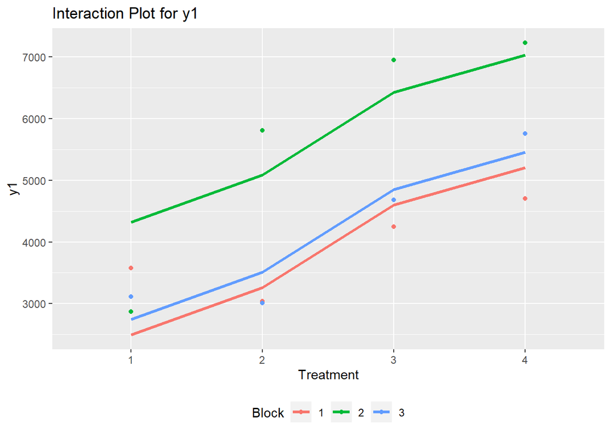

```r
lm1 <- lm(y1~Treatment + Block,data=Nitrogen)

Pred1 = predict(lm1)
Nitrogen$Pred <- Pred1

ggplot(data = Nitrogen,aes(x=Treatment,group=Block))+
  geom_line(aes(y=Pred1,col=Block),lwd=1.2)+
  geom_point(aes(y=y1,col=Block))+
  labs(x = 'Treatment',y = 'y1')+
  ggtitle("Interaction Plot for y1")+
  theme(legend.position = "bottom")
```

The univariate outputs for each model:

```r
print("Anova Type I SS:")
anova(lm1)
print("Anova Type III SS:")
Anova(lm1,type=3)
```

```
## [1] "Anova Type I SS:"
```

```
## Analysis of Variance Table
##
## Response: y1
##           Df   Sum Sq Mean Sq F value  Pr(>F)
## Treatment  3 13729558 4576519  5.4353 0.03802 *
## Block      2  7817850 3908925  4.6424 0.06049 .
## Residuals  6  5052017  842003
## ---
## Signif. codes:  0 '***' 0.001 '**' 0.01 '*' 0.05 '.' 0.1 ' ' 1
```

```
## [1] "Anova Type III SS:"
```

```
## Anova Table (Type III tests)
##
## Response: y1
##               Sum Sq Df F value   Pr(>F)
## (Intercept) 12466689  1 14.8060 0.008481 **
## Treatment   13729558  3  5.4353 0.038018 *
## Block        7817850  2  4.6424 0.060488 .
## Residuals    5052017  6
## ---
## Signif. codes:  0 '***' 0.001 '**' 0.01 '*' 0.05 '.' 0.1 ' ' 1
```

```r
lm2 <- lm(y2~Treatment + Block,data=Nitrogen)
print("Anova Type I SS:")
anova(lm2)
print("Anova Type III SS:")
Anova(lm2,type=3)
```

```
## [1] "Anova Type I SS:"
```

```
## Analysis of Variance Table
##
## Response: y2
##           Df   Sum Sq Mean Sq F value   Pr(>F)
## Treatment  3 24868100 8289367 16.5677 0.002621 **
## Block      2  2546067 1273033  2.5444 0.158419
## Residuals  6  3002000  500333
## ---
## Signif. codes:  0 '***' 0.001 '**' 0.01 '*' 0.05 '.' 0.1 ' ' 1
```

```
## [1] "Anova Type III SS:"
```

```
## Anova Table (Type III tests)
##
## Response: y2
##                Sum Sq Df  F value    Pr(>F)
## (Intercept) 123297339  1 246.4304 4.234e-06 ***
## Treatment    24868100  3  16.5677  0.002621 **
## Block         2546067  2   2.5444  0.158419
## Residuals     3002000  6
## ---
## Signif. codes:  0 '***' 0.001 '**' 0.01 '*' 0.05 '.' 0.1 ' ' 1
```

```r
lm3 <- lm(y3~Treatment + Block,data=Nitrogen)
print("Anova Type I SS:")
anova(lm3)
print("Anova Type III SS:")
Anova(lm3,type=3)
```

```
## [1] "Anova Type I SS:"
```

```
## Analysis of Variance Table
##
## Response: y3
##           Df Sum Sq Mean Sq F value  Pr(>F)
## Treatment  3  31660 10553.2 22.7385 0.00112 **
## Block      2   2609  1304.3  2.8104 0.13764
## Residuals  6   2785   464.1
## ---
## Signif. codes:  0 '***' 0.001 '**' 0.01 '*' 0.05 '.' 0.1 ' ' 1
```

```
## [1] "Anova Type III SS:"
```

```
## Anova Table (Type III tests)
##
## Response: y3
##             Sum Sq Df  F value    Pr(>F)
## (Intercept) 135027  1 290.9362 2.598e-06 ***
## Treatment    31660  3  22.7385   0.00112 **
## Block         2609  2   2.8104   0.13764
## Residuals     2785  6
## ---
## Signif. codes:  0 '***' 0.001 '**' 0.01 '*' 0.05 '.' 0.1 ' ' 1
```

The output from the `manova()` function in R gives a multivariate analysis of variance, which groups the values found in the three individual `Anova(,type=3)` outputs above. We have already seen the test blocks, but we also have:

```r
print("Error SSCP Matrix:")
Ano.fit$SSPE
print("Error SSCP Matrix for Treatment and Block:")
Ano.fit$SSP
```

```
## [1] "Error SSCP Matrix:"
```

```
##         [,1]       [,2]       [,3]
## [1,] 5052017 3065116.67 -38485.000
## [2,] 3065117 3002000.00 -45766.667
## [3,]  -38485  -45766.67   2784.667
```

```
## [1] "Error SSCP Matrix for Treatment and Block:"
```

```
## $Treatment
##            [,1]       [,2]       [,3]
## [1,] 13729558.3  9832783.3 -495547.50
## [2,]  9832783.3 24868100.0 -554688.33
## [3,]  -495547.5  -554688.3   31659.58
##
## $Block
##         [,1]       [,2]       [,3]
## [1,] 7817850 4025850.00 -49845.000
## [2,] 4025850 2546066.67 -58583.333
## [3,]  -49845  -58583.33   2608.667
```

That means that we here have all the information we need to do univariate tests of significance!

Further these matrices have a direct connection to section 4.3.2 page 304. We see that:

Q.1: **E = Error SSCP Matrix**

Q.2: **H = Type III SSCP Matrix for Treatment**

Q.3: **H = Type III SSCP Matrix for Block**

Let us try it out. The test-statistic for treatment is given in theorem 4.26 on page 306:
$$\frac{\det(q_1)}{\det(q_1+q_2)} =
\frac{1.1840\cdot10^{16}}{5.8515\cdot10^{18}} = 0.002$$

Which is the Wilks Lambda!

```r
Ano.fit
```

```
##
## Type II MANOVA Tests: Wilks test statistic
##           Df test stat approx F num Df den Df   Pr(>F)
## Treatment  3  0.002023  12.9511      9 9.8856 0.000222 ***
## Block      2  0.193450   1.6981      6 8.0000 0.238705
## ---
## Signif. codes:  0 '***' 0.001 '**' 0.01 '*' 0.05 '.' 0.1 ' ' 1
```